# Question

Si la mediana de la asistencia a las cinco auditorios de un centro cultural es 376 y no hay dos auditorios con el mismo número de espectadores, ¿cuál es el mayor valor posible para “N”?

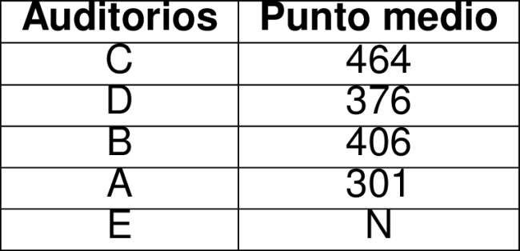

## Answerlist

- 375
- 376
- 363
- 381

# Solution

### Análisis del problema

Para resolver este problema, necesitamos entender qué significa que la mediana sea 376 en un conjunto de 5 valores.

**Datos conocidos:** - Tenemos 5 auditorios: C, D, B, A, E - Sus valores son: 464, 376, 406, 301, N - La mediana del conjunto es 376 - No hay dos valores iguales

### Concepto de mediana

La mediana de 5 valores ordenados de menor a mayor es el valor que ocupa la **posición central (posición 3)**.

Para que la mediana sea 376, cuando ordenemos los 5 valores de menor a mayor, el valor en la posición 3 debe ser exactamente 376.

### Análisis de casos

Los valores conocidos son: 301, 406, 464, 376

Analicemos dónde puede ubicarse N para que la mediana sea 376:

**Caso 3:** Si N = 376 - No es válido porque no puede haber valores iguales

**Caso 4:** Si N > 376 - El valor 376 no estaría en posición 3 - Mediana diferente de 376

### Conclusión

El **mayor valor posible** para N es **375** (justo menor que 376).

## Answerlist

- Verdadero
- Falso
- Falso
- Falso

# Meta-information

exname: mediana_asistencia_salas_cine extype: schoice exsolution: 1000 exshuffle: TRUE exsection: Estadística|Medidas de posición|Mediana|Interpretación exextra[Type]: Interpretación y representación exextra[Level]: 2 exextra[Language]: es exextra[Course]: Matemáticas ICFES